# Clase13_py_poo

**Autor: Luis Fernando Apáez Álvarez**  
-Curso PyM-  
Clase 13: Paquetes distribuibles  
Fecha: 01 de diciembre del 2022

### Contenido

- Creando un paquete distribuible
- Instalación del paquete

Desde las últimas clases hemos visto la ventaja de crear paquetes para organizar y reutilizar código. Asimismo, logramos trabajar con paquetes (archivos) los cuales se encuentran alojados en la misma ubicación que nuestros archivos *.py*. En esta clase veremos como trabajar con paquetes que no se encuentran necesariamente en la misma ubicación, de donde éstos reciben el nombre de **paquetes distribuibles**. Además, podremos compartirlos (distribuirlos) con otras personas, ya sea enviándolos o subiéndolos a alguna plataforma como *Github*.

Como ejemplos simples de paquetes distribuibles son todos aquellos paquetes que hemos descargado utilizando `pip install`.

Recordemos que desde el archivo `Prueba.py` importabamos del paquete `App_Mat` y del subpaquete `derivadas` la función `Algebraicas()` del archivo `calculos_derivadas.py`

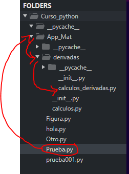

No obstante, si tuvieramos en otra ubicación el archivo `Prueba.py` al momento de intentar ejecutar el código que teníamos en él:

```
import sympy as sp

# ----------------------------------------------------------

from App_Mat.derivadas.calculos_derivadas import Algebraicas

# definimos el símbolo
x = sp.Symbol('x')

# utilizamos la función
derivada_y = Algebraicas(x ** 2)

print(derivada_y)
```

obtendríamos seguramente un error. La ventaja de los paquetes distribuibles es que podemos llamarlos desde cualquier sitio o archivo.

## Creando un paquete distribuible

Comenzaremos por crear el archivo `setup.py` el cual contendrá una descripción (nombre, descripción, autor, etcétera) del paquete que deseamos distribuir. Este archivo lo crearemos desde la raíz de la carpeta con la cual estamos trabajando:

[figure not shown]

en la carpeta `Curso_python` damos click derecho (1) y seleccionamos la opción de *new file*, después vemos en la ventana de la derecha que el documento nuevo se ha creado (2). Después de guardar dicho archivo y colocarle el nombre indicado de `setup.py` vemos que éste ha aparecido en el menú de *folders*

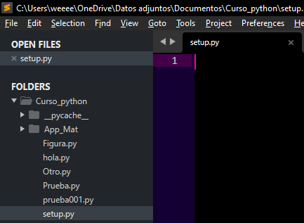

Ahora bien, dentro de dicho archivo comenzamos por escribir:

```
# Importamos el módulo setup
from setuptools import setup

# Utilizamos la función setup() para crear la descripción

setup(

    # Colocamos el nombre del paquete
    name = "paquete App_Mat"
)
```

Nuestro objetivo será poder utilizar la función `Algebraicas()` desde cualquier archivo, de modo que buscamos distribuir el subpaquete `derivadas` del paquete `App_Mat`. Continuando escribiendo:

```
# .
# .
setup(

    # Colocamos el nombre del paquete
    name = "paquete App_Mat",

    # Colocamos la versión del paquete
    version = "1.0",

    # Colocamos una breve descripción
    description = "Paquete de cálculo de derivadas algebraicas",

    # Colocamos el autor
    author = "Luis",

    # Opcional: correo electrónico
    author_email = "luisapaez31416@gmail.com",

    # Opcional: URL

    # Dónde se encuentra el paquete o subpaquete que queremos empaquetar
    packages = ["App_Mat", "App_Mat.derivadas"]
)
```

donde en `packages = []` colocamos primero el nombre del paquete seguido del nombre *completo* del subpaquete en cuestión. Después guardamos cambios y básicamente ya hemos configurado el `setup.py`.

Ahora, vamos a la carpeta dónde creamos el *setup* (en el explorador de archivos):

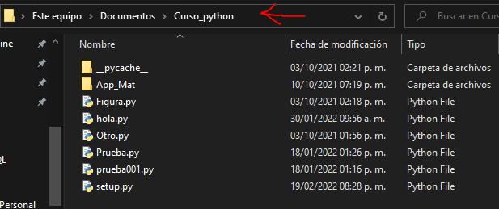

donde extraeremos la dirección de dicha carpeta. Después abrimos *símbolos del sistema* y configuramos a la dirección de la carpeta que contiene el archivo `setup.py`:

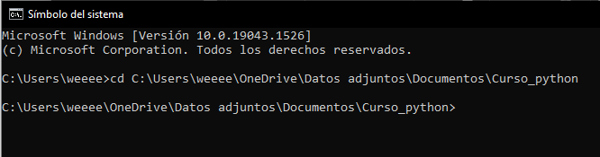

ahí colocaremos lo siguiente para configurar nuestro paquete distribuible

```
python setup.py sdist
```

que después de ejecutar nos arrojará algo como

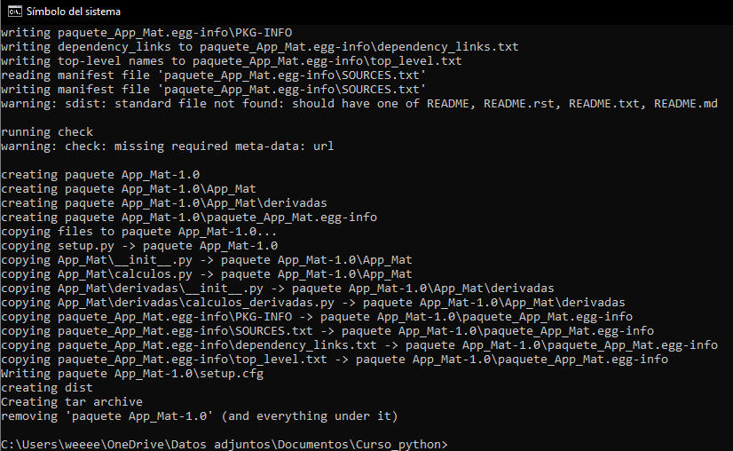

Vemos que en automático se han creado dos carpetas:

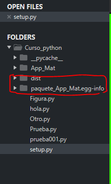

Dentro de la carpeta `dist` hay un archivo importante:

[figure not shown]

con el cual podemos compartir el paquete que hemos creado. Ahora si, podemos utilizar la función `Algebraicas()` desde cualquier archivo python desde cualquier ubicación de nuestro ordenador.

Como ejemplo instalaremos dicho paquete en nuestro propio ordenador.

## Instalación del paquete

Nuevamente desde *símbolos del sistema* configuramos ahora la dirección donde se almacena el archivo anterior, para ello nos dirigimos a la carpeta `dist`. Después escribimos

```
pip install "paquete App_Mat-1.0.tar.gz"
```

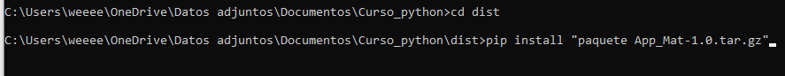

después de ejecutar veremos algo como:

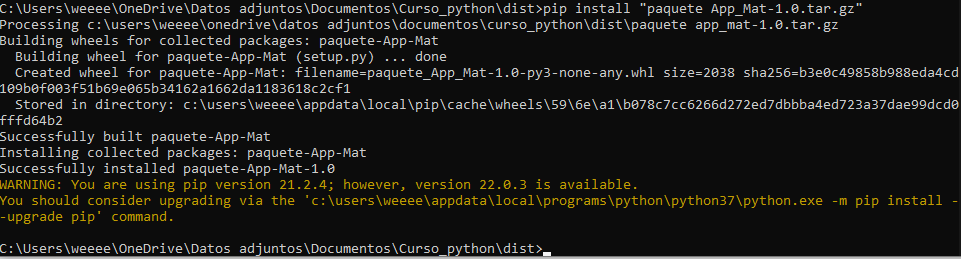

Pongamos aprueba lo que hemos hecho, para ello crearemos un archivo `.py` desde otra ubicación de nuestro ordenador.

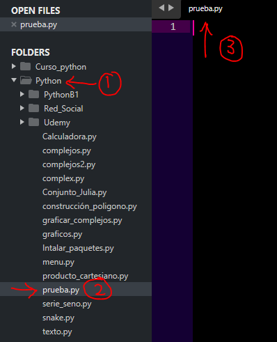

desde la carpeta `Python` (1) creamos el archivo `prueba.py` (2) el cual se muestra en la ventana de la derecha (3).

Ahora, si ejecutamos el siguiente código vemos que todo ha salido correctamente y sin errores, a pesar que el archivo no se encuentra en la misma ubicación que el paquete `App_Mat`

[figure not shown]